# LDA-Assignment 3 - Ermi’s Script

Ermioni Athanasiadi

2026-01-09

To Do Ermi: - check why lmm produces different model results than in report 1 - use numeric time and scaled to 0-6 before imputing datasets - standardize coefficients in lmm of report 1 to be able to compare with MI-version - investigate singularity issues in glmm/gee mice imputation - try out weighted GEE - try to succeed with wide format imputation

```r
library(haven)
library(tidyverse)
library(patchwork)
library(pROC)
library(nlme)
library(lme4)
library(data.table)
```

```r
library(broom)
library(lattice)
library(sjPlot)
library(xtable)
library(kableExtra)
library(mice)
library(miceadds)
library(geepack)
library(mitml)
library(lmerTest)
library(broom.mixed)
```

```r
setwd("./data")

filename <- "alzheimer25.sas7bdat"

dat <- read_sas(filename)
# dat_dt <- setDT(read_sas(filename))
```

# Data Preparation

```r
reshape_dat <- function(dat) {
    dat_long <- dat %>%
        pivot_longer(
            cols = matches("^(bprs|cdrsb|abpet|taupet)\\d+"),
            names_to = c(".value", "time"),
            names_pattern = "(.+)(\\d+)"
        )
    dat_long
}

to_factor <- function(dat) {
    dat <- dat %>%
        mutate(
            sex = as.factor(sex),
            edu = as.factor(edu),
            trial = as.factor(trial),
            job = as.factor(job),
            wzc = as.factor(wzc),
            patid_fct = as.factor(patid)
        )
    dat
}

dat <- to_factor(dat)
dat_long <- reshape_dat(dat)


dat_long <- dat_long %>%
    mutate(
        time = as.factor(time),  # levels 0-6
        time_num = as.numeric(time)   # values 1-7
    )


# Baseline per subject (year 0)
base <- dat_long %>%
  filter(time == 0) %>%
  transmute(
    patid, trial,
    # Age = age, Sex = sex, Edu = edu, BMI = bmi, Job = job, Income = inkomen,
    # ADL = adl, WZC = wzc,
    cdrsb0 = cdrsb,
    abpet0 = abpet,
    taupet0 = taupet
  )

# Add baseline + time to all rows
dat_long <- dat_long %>%
  left_join(base, by = c("patid","trial"))

rm(base)

dat_long <- dat_long %>%
    mutate(
        time_num0 = dat_long$time_num - 1
    )

dat_long_scaled <- dat_long
vars_to_scale <- c("time_num", "age", "bmi", "adl", "abpet", "taupet", "bprs")
dat_long_scaled[vars_to_scale] <- sapply(dat_long_scaled[vars_to_scale], scale)
```

Now prepare for the binary outcome:

```r
dat_long_bin <- dat_long %>%
  # Drop missing outcomes
  # Binary outcome: 1 = severe (>10), 0 = non-severe
  mutate(
    cdrsb_bin = as.factor(as.character(ifelse(cdrsb > 10, 1, 0))),
    time_num0 = dat_long$time_num - 1
  )

dat_long_bin_scaled <- dat_long_bin
vars_to_scale <- c("time_num", "age", "bmi", "adl", "abpet", "taupet", "bprs")
dat_long_bin_scaled[vars_to_scale] <- sapply(dat_long_bin_scaled[vars_to_scale], scale)
```

# Explore Missingness

```r
dat_check <- dat_long %>%
    arrange(patid, time_num) %>%
    group_by(patid) %>%
    mutate(
        miss = is.na(bprs),
        miss_started = cummax(miss)
    )


missingness_pattern <- dat_check %>%
    summarise(
        any_missing = any(miss),
        intermittent = any(!miss & miss_started),
        monotone = any_missing & !intermittent
    )

missingness_pattern %>%
    count(monotone)
```

```
## # A tibble: 2 × 2
##   monotone     n
##   <lgl>    <int>
## 1 FALSE      511
## 2 TRUE       742
```

```r
missingness_pattern %>%
    count(intermittent)
```

```
## # A tibble: 1 × 2
##   intermittent     n
##   <lgl>        <int>
## 1 FALSE         1253
```

Ok, we have verified that we have no intermittent missingness. Let’s now consider our models from the previous assignments and use MI to deal with the incomplete data.

# Question 4

## For LMM:

```r
# m5 from assignment1
model_lmm <- lmer(bprs ~ time_num0 * (sex + age + adl + job + cdrsb0) + wzc + taupet0 + abpet0 + (time_num0 | trial/patid),
           data = dat_long, REML = FALSE)
```

```
## boundary (singular) fit: see help('isSingular')
```

```r
summary(model_lmm)
```

```
## Linear mixed model fit by maximum likelihood . t-tests use Satterthwaite's
##   method [lmerModLmerTest]
## Formula: bprs ~ time_num0 * (sex + age + adl + job + cdrsb0) + wzc + taupet0 +
##     abpet0 + (time_num0 | trial/patid)
##    Data: dat_long
##
##       AIC       BIC    logLik -2*log(L)  df.resid
##   27150.9   27299.1  -13553.5   27106.9      6198
##
## Scaled residuals:
##     Min      1Q  Median      3Q     Max
## -3.6685 -0.5937 -0.0087  0.5928  3.3020
##
## Random effects:
##  Groups      Name        Variance Std.Dev. Corr
##  patid:trial (Intercept)  0.6182  0.7862
##              time_num0    0.6773  0.8230   0.37
##  trial       (Intercept) 12.3332  3.5119
##              time_num0    0.0105  0.1025   -1.00
##  Residual                 2.6976  1.6425
## Number of obs: 6220, groups:  patid:trial, 1253; trial, 25
##
## Fixed effects:
##                    Estimate Std. Error         df t value Pr(>|t|)
## (Intercept)      -3.051e+01  2.806e+00  1.029e+03 -10.874  < 2e-16 ***
## time_num0         3.683e+00  6.405e-01  8.121e+02   5.750 1.26e-08 ***
## sex1             -1.533e-01  8.970e-02  1.180e+03  -1.709  0.08768 .
## age               1.493e+00  3.021e-02  1.174e+03  49.423  < 2e-16 ***
## adl              -5.351e-01  8.495e-02  1.191e+03  -6.299 4.20e-10 ***
## job1             -1.102e+00  5.883e-01  1.173e+03  -1.874  0.06117 .
## cdrsb0           -1.933e-02  5.878e-03  1.189e+03  -3.288  0.00104 **
## wzc1              1.912e+00  1.002e-01  1.274e+03  19.085  < 2e-16 ***
## taupet0           1.874e-01  4.597e-01  2.198e+03   0.408  0.68359
## abpet0            5.687e-02  1.603e-01  1.222e+03   0.355  0.72291
## time_num0:sex1   -4.459e-02  6.211e-02  9.989e+02  -0.718  0.47296
## time_num0:age     3.929e-02  7.048e-03  8.229e+02   5.575 3.36e-08 ***
## time_num0:adl     1.159e-01  2.524e-02  9.570e+02   4.593 4.96e-06 ***
## time_num0:job1   -8.449e-01  1.935e-01  9.037e+02  -4.367 1.41e-05 ***
## time_num0:cdrsb0 -2.136e-02  4.145e-03  9.714e+02  -5.154 3.10e-07 ***
## ---
## Signif. codes:  0 '***' 0.001 '**' 0.01 '*' 0.05 '.' 0.1 ' ' 1
```

```
##
## Correlation matrix not shown by default, as p = 15 > 12.
## Use print(x, correlation=TRUE)  or
##     vcov(x)        if you need it
```

```
## fit warnings:
## Some predictor variables are on very different scales: consider rescaling
## optimizer (nloptwrap) convergence code: 0 (OK)
## boundary (singular) fit: see help('isSingular')
```

#### Mice: Wide Format:

##### missing data exploration

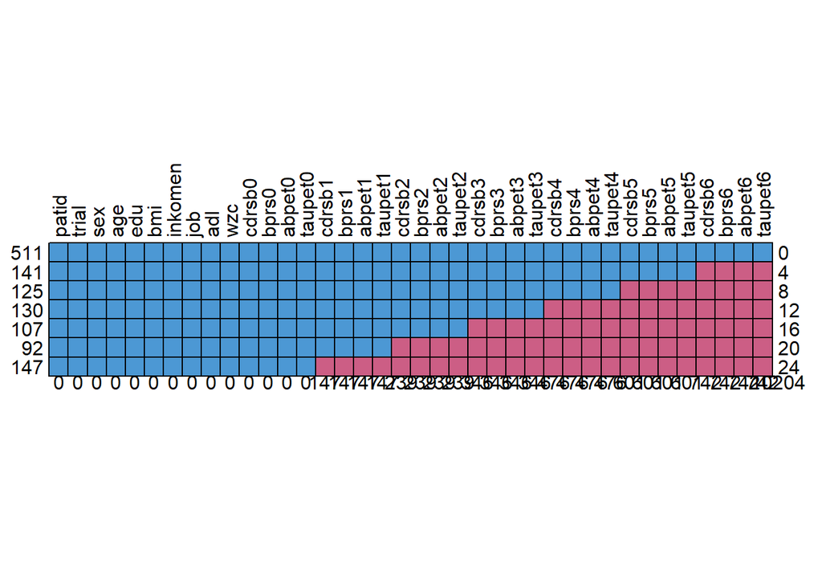

```
##     patid trial sex age edu bmi inkomen job adl wzc cdrsb0 bprs0 abpet0 taupet0
## 511     1     1   1   1   1   1       1   1   1   1      1     1      1       1
## 141     1     1   1   1   1   1       1   1   1   1      1     1      1       1
## 125     1     1   1   1   1   1       1   1   1   1      1     1      1       1
## 130     1     1   1   1   1   1       1   1   1   1      1     1      1       1
## 107     1     1   1   1   1   1       1   1   1   1      1     1      1       1
## 92      1     1   1   1   1   1       1   1   1   1      1     1      1       1
## 147     1     1   1   1   1   1       1   1   1   1      1     1      1       1
##         0     0   0   0   0   0       0   0   0   0      0     0      0       0
##     cdrsb1 bprs1 abpet1 taupet1 cdrsb2 bprs2 abpet2 taupet2 cdrsb3 bprs3 abpet3
## 511      1     1      1       1      1     1      1       1      1     1      1
## 141      1     1      1       1      1     1      1       1      1     1      1
## 125      1     1      1       1      1     1      1       1      1     1      1
## 130      1     1      1       1      1     1      1       1      1     1      1
## 107      1     1      1       1      1     1      1       1      0     0      0
```

[output cut: 21 more lines]

```r
# use dataset in the wide format

dat %>% select(-patid_fct) %>%
    md.pattern(rotate.names = T)
```

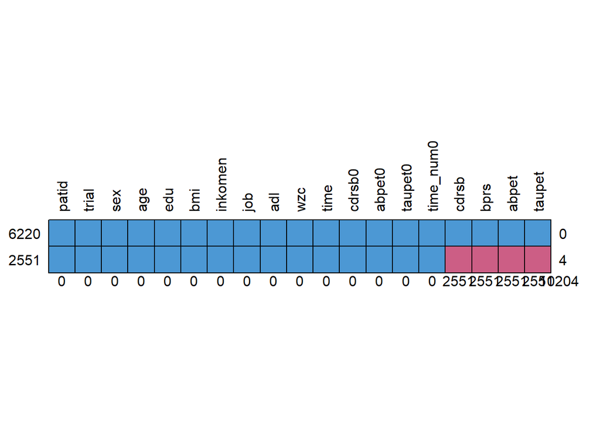

```
##      patid trial sex age edu bmi inkomen job adl wzc time cdrsb0 abpet0 taupet0
## 6220     1     1   1   1   1   1       1   1   1   1    1      1      1       1
## 2551     1     1   1   1   1   1       1   1   1   1    1      1      1       1
##          0     0   0   0   0   0       0   0   0   0    0      0      0       0
##      time_num0 cdrsb bprs abpet taupet
## 6220         1     1    1     1      1     0
## 2551         1     0    0     0      0     4
##              0  2551 2551  2551   2551 10204
```

```r
dat_long %>% select(-patid_fct, -time_num) %>%
    md.pattern(rotate.names = T)
```

```r
sapply(dat_long %>% select(-patid_fct, -time_num), function(x) mean(is.na(x)*100))
```

```
##     patid     trial       sex       age       edu       bmi   inkomen       job
##   0.00000   0.00000   0.00000   0.00000   0.00000   0.00000   0.00000   0.00000
##       adl       wzc      time     cdrsb      bprs     abpet    taupet    cdrsb0
##   0.00000   0.00000   0.00000  29.08448  29.08448  29.08448  29.08448   0.00000
##    abpet0   taupet0 time_num0
##   0.00000   0.00000   0.00000
```

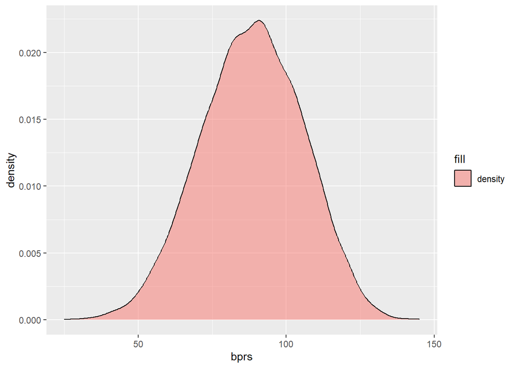

```r
ggplot(dat_long, aes(x=bprs, fill="density")) +
  geom_density(alpha=0.5)
```

Ok, we have 29.1% missingness in four variables (long format): In the three covariates cdrsb, abpet, taupet and the incomplete outcome bprs. Though we will not use the full variables of cdrsb, abpet and taupet in our analysis model (but only the baseline values, which are complete), we will still add the full but incomplete variables to our imputation model. They will serve as auxiliary variables. Thus, we will impute all four variables.

Lets now set up mice:

##### Mice setup

```r
# prepare dataframe (wide format)
dat_mice <- dat %>%
    select(-patid_fct) %>%
    mutate(
    patid = as.integer(patid)  # make sure id variable is integer
    )

# imputation method
meth <- make.method(dat_mice)
# set method for all incomplete vars except bprs to 0 -> dont impute
meth[c(paste0("taupet", 0:6))] <- "pmm"
meth[c(paste0("abpet", 0:6))] <- "pmm"
meth[c(paste0("cdrsb", 0:6))] <- "pmm"
meth[paste0("bprs", 0:6)] <- "pmm"
meth
```

```
##   patid   trial     sex     age     edu     bmi inkomen     job     adl     wzc
##      ""      ""      ""      ""      ""      ""      ""      ""      ""      ""
##  cdrsb0  cdrsb1  cdrsb2  cdrsb3  cdrsb4  cdrsb5  cdrsb6   bprs0   bprs1   bprs2
##   "pmm"   "pmm"   "pmm"   "pmm"   "pmm"   "pmm"   "pmm"   "pmm"   "pmm"   "pmm"
##   bprs3   bprs4   bprs5   bprs6  abpet0  abpet1  abpet2  abpet3  abpet4  abpet5
##   "pmm"   "pmm"   "pmm"   "pmm"   "pmm"   "pmm"   "pmm"   "pmm"   "pmm"   "pmm"
##  abpet6 taupet0 taupet1 taupet2 taupet3 taupet4 taupet5 taupet6
##   "pmm"   "pmm"   "pmm"   "pmm"   "pmm"   "pmm"   "pmm"   "pmm"
```

```r
# predictor matrix
pred <- make.predictorMatrix(dat_mice)
pred[, "patid"] <- 0  # grouping variable id: see van Buuren (2018, p.147) -> "Identification variables such as subject ID numbers have no predictive value and should be excluded from the imputation model.”
```

We have to choose an imputation method. As we deal with hierarchical data, we could also impute in the long format by using the 2l. methods provided by the miceadds package. We have missing data only on level 2 (i.e. the time / repeated measurements level).

Bprs is numeric and are assumed to be a continuous variable. Lets impute it with predictive mean matching (pmm), as its a semi-parametric and thus robust method and produces only plausible values, because it samples from observed donor cases.

We start with k=5 donor cases for drawing imputed values.

##### Imputation

```r
imp.lmm <- mice(dat_mice, method = meth, predictorMatrix = pred, m = 10, donors = 5, maxit = 50, seed = 1212, print = F)
```

##### Post-imputation diagnostics

```r
imp.1 <- imp.lmm

conv <- convergence(imp.1, diagnostic = "all")

conv.imputed <- conv %>%
    filter(vrb %in% c(paste0("bprs", 1:6)) |
           vrb %in% c(paste0("cdrsb", 1:6)) |
           vrb %in% c(paste0("abpet", 1:6)) |
           vrb %in% c(paste0("taupet", 1:6))
               )

conv.imputed
```

```
##      .it     vrb            ac      psrf
## 1      1  cdrsb1            NA 1.0952013
## 2      2  cdrsb1  6.228316e-01 1.3850726
## 3      3  cdrsb1  6.638226e-01 1.3883878
## 4      4  cdrsb1  4.765360e-01 1.0692547
## 5      5  cdrsb1  3.783680e-01 1.0495107
## 6      6  cdrsb1  4.373472e-01 1.1590991
## 7      7  cdrsb1  3.854696e-01 1.1797588
## 8      8  cdrsb1  3.206270e-01 1.1055842
## 9      9  cdrsb1  2.057580e-01 1.0784572
## 10    10  cdrsb1  2.160296e-01 1.0706719
## 11    11  cdrsb1  2.360377e-01 1.0618657
## 12    12  cdrsb1  2.673198e-01 1.0574830
## 13    13  cdrsb1  2.869109e-01 1.0684085
## 14    14  cdrsb1  2.663471e-01 1.0390541
```

[output cut: 1186 more lines]

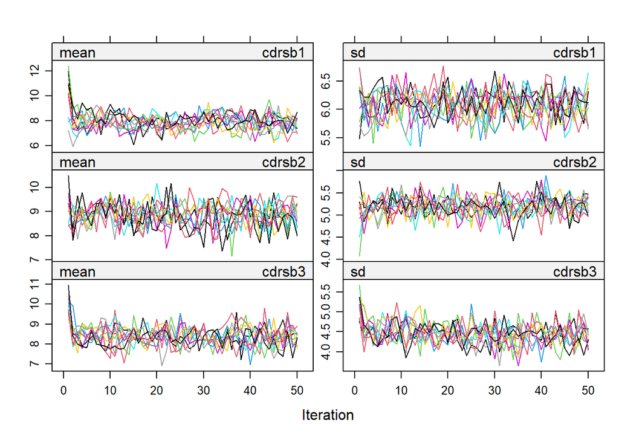

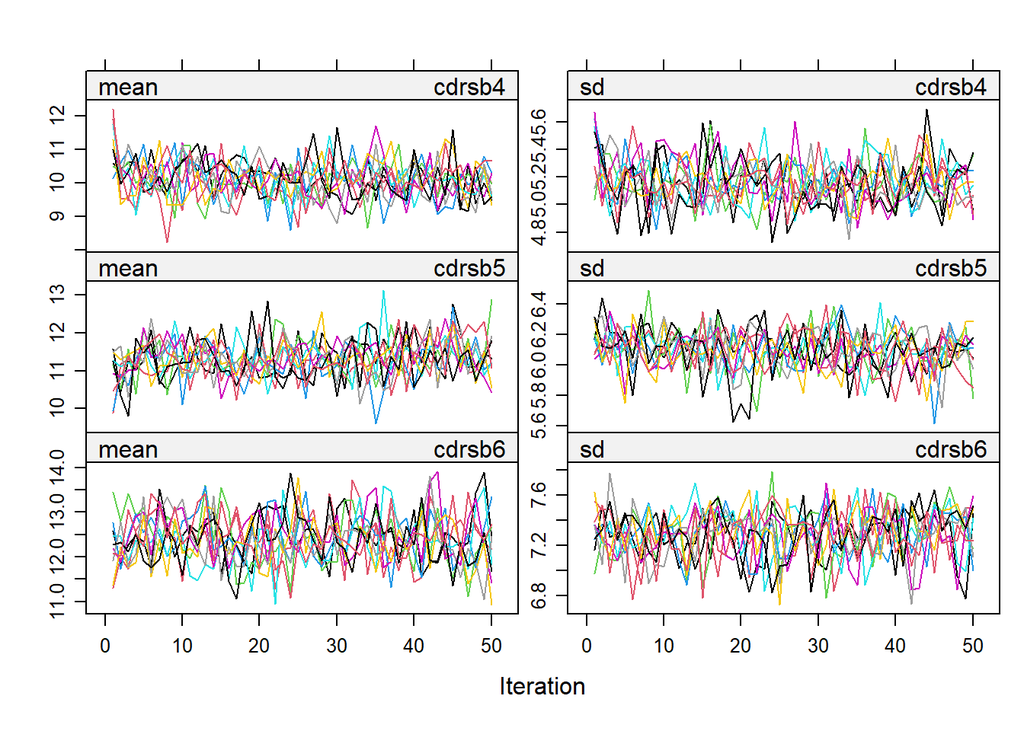

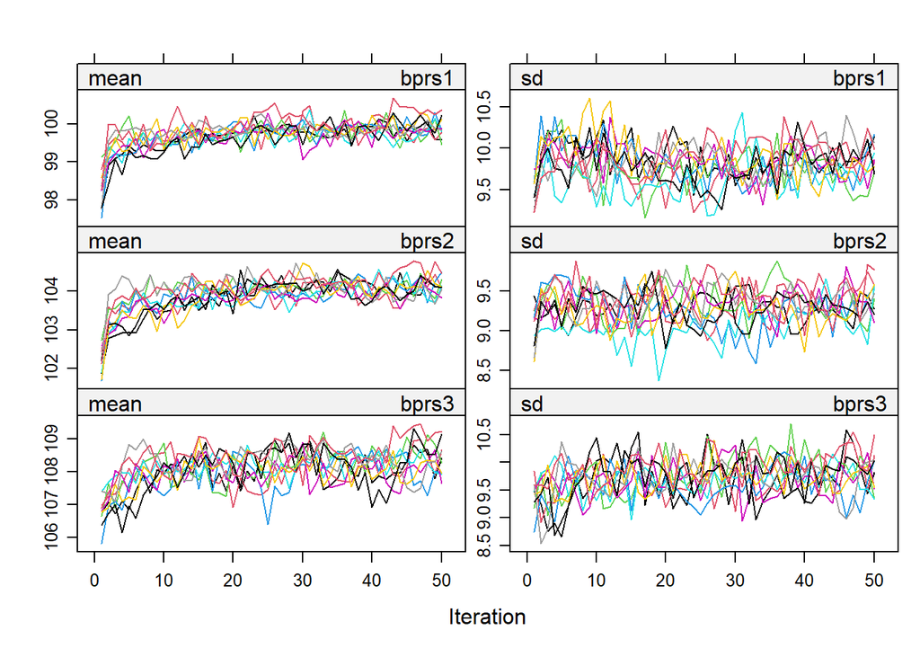

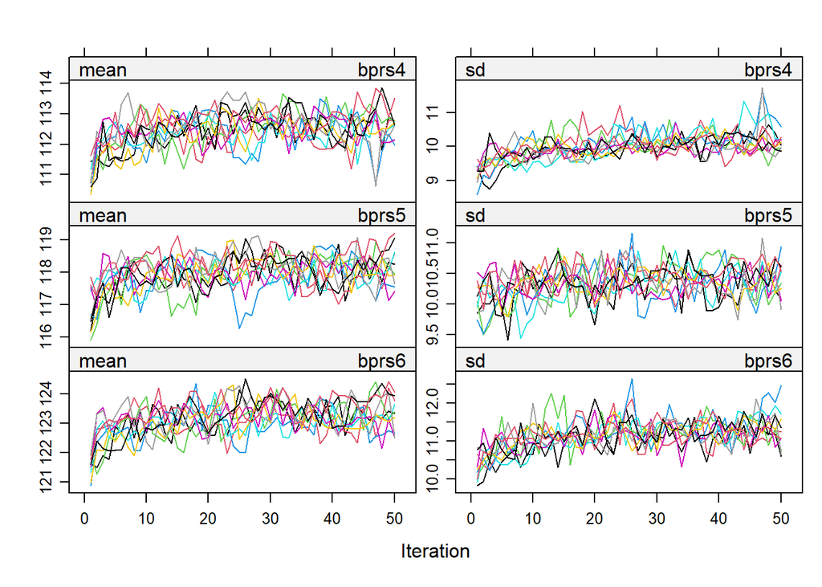

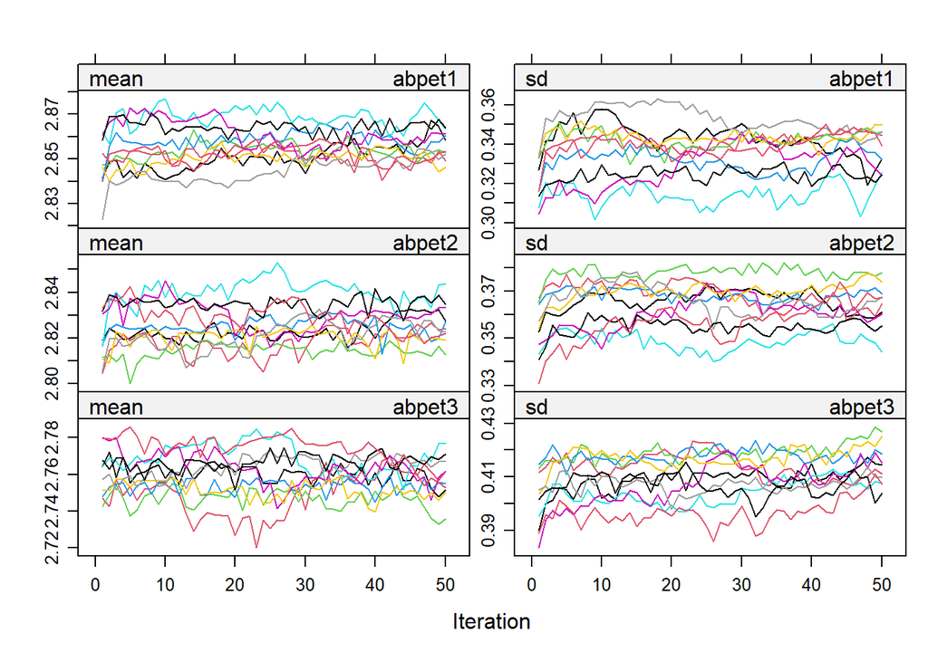

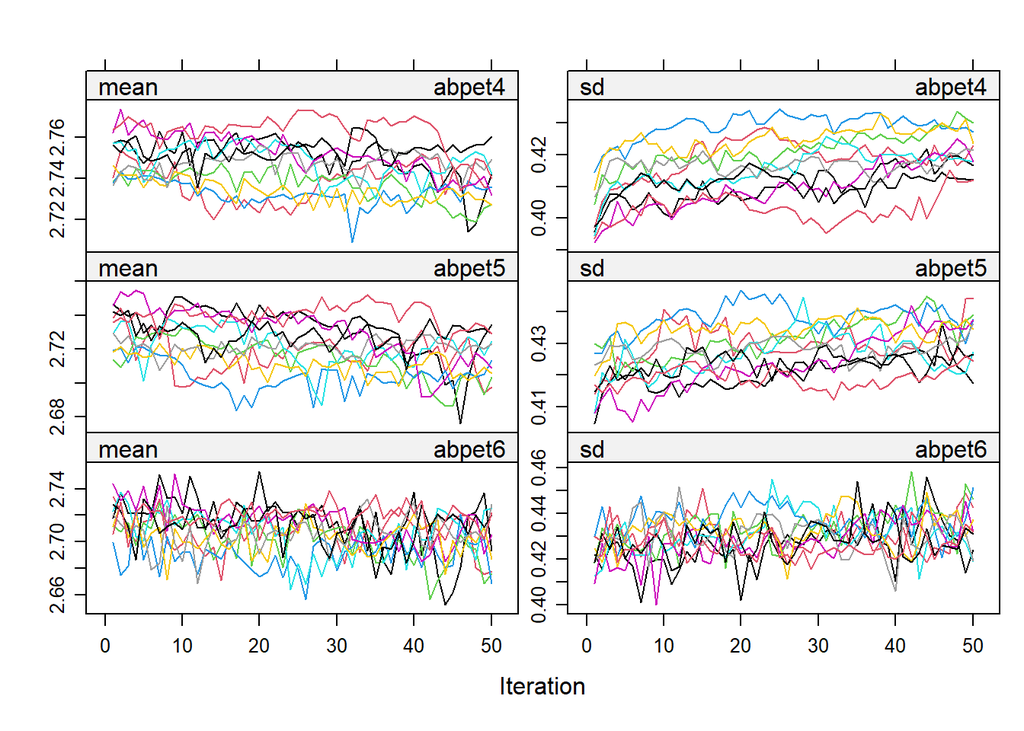

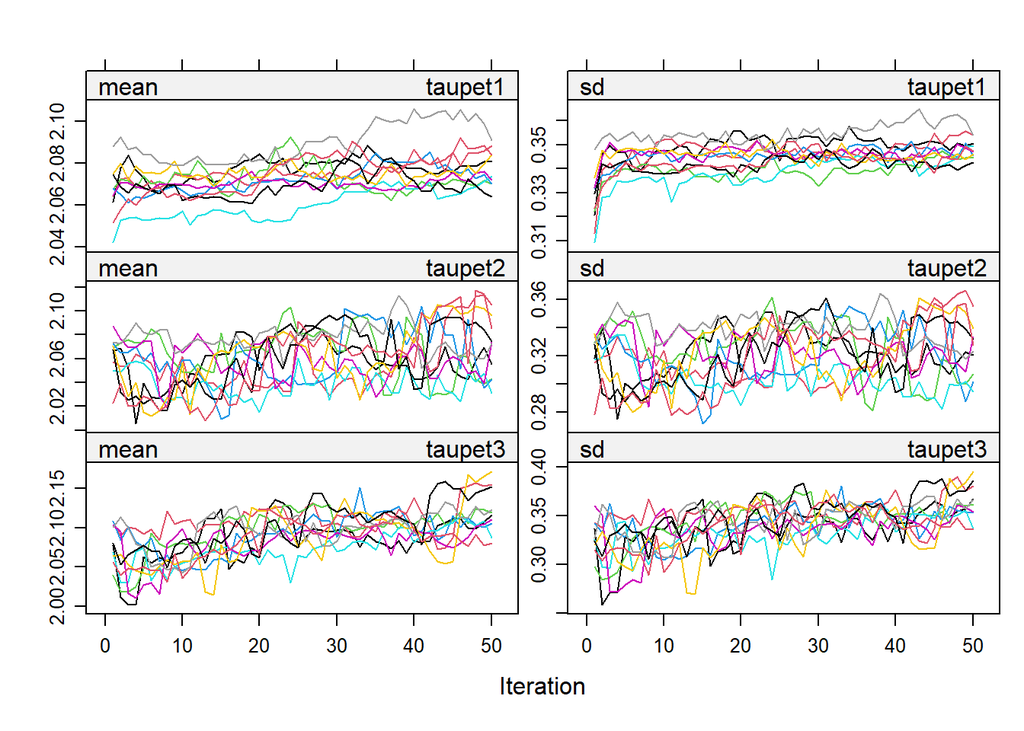

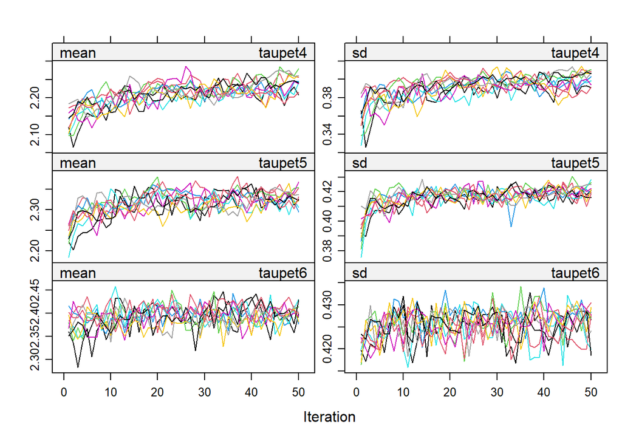

```r
plot(imp.1)
```

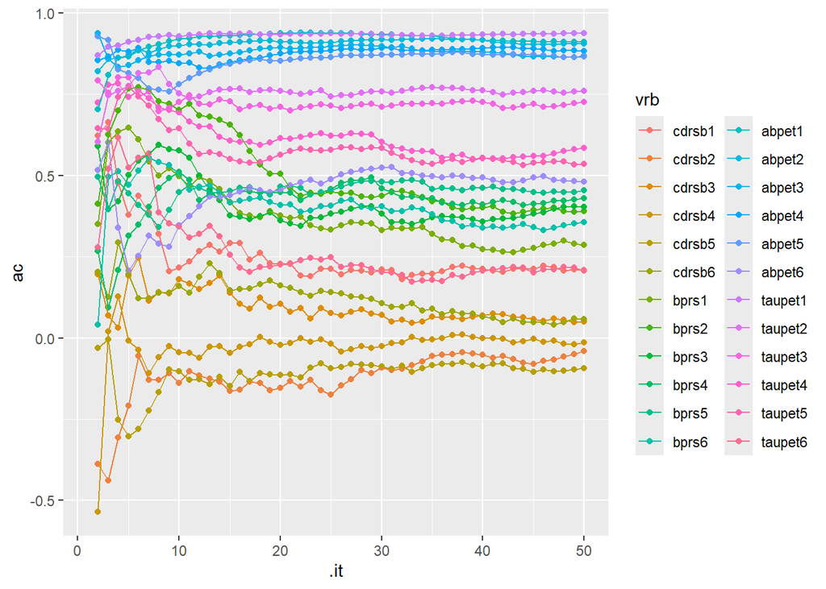

```r
ggplot(conv.imputed, aes(x = .it, y = ac, colour = vrb)) +
    geom_point() +
    geom_line()
```

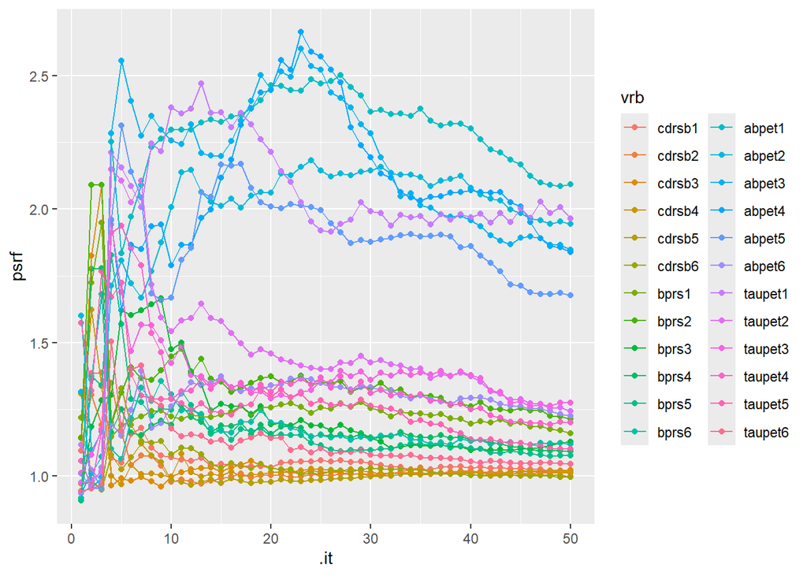

```r
ggplot(conv.imputed, aes(x = .it, y = psrf, colour = vrb)) +
    geom_point() +
    geom_line()
```

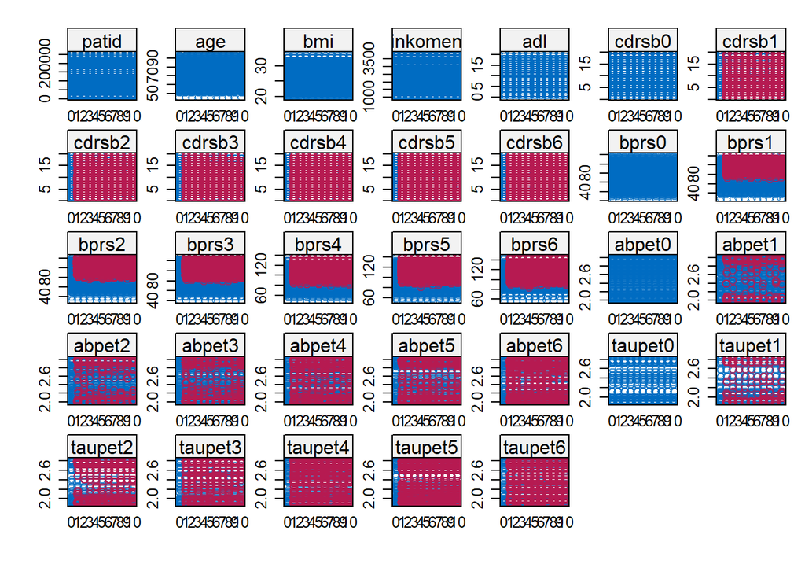

```r
stripplot(imp.1)
```

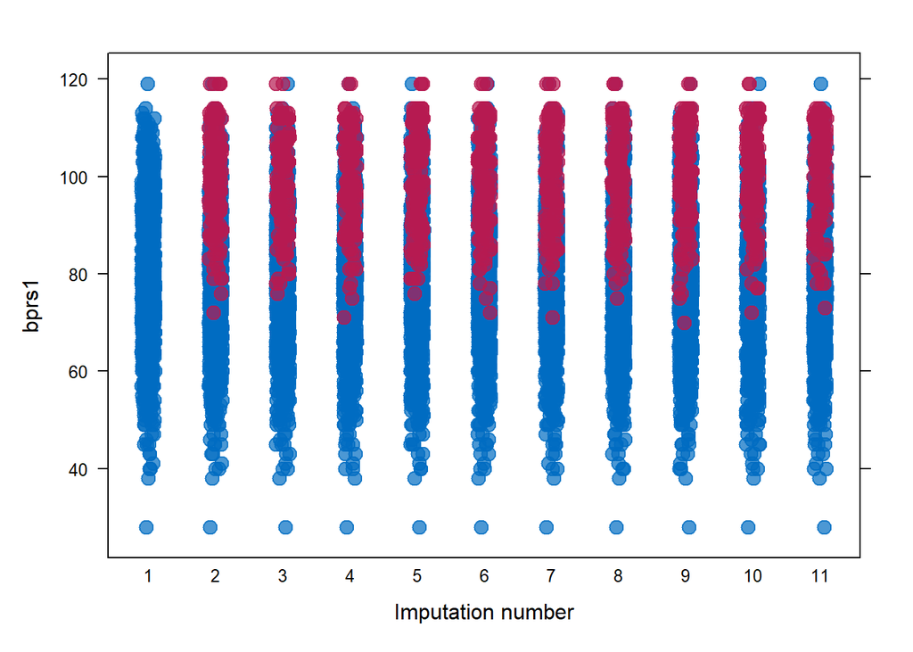

```r
stripplot(imp.1, bprs1~.imp, pch=20, cex=2)  # blue: observed data, red: imputed data
```

In the stripplot, we can see that primarily high values of bprs are imputed in the first measurement year. This could also be investigated for the other time points.

##### back-transform imputed datasets to long format

```r
implist_wide <- mids2mitml.list(imp.1)

implist_long <- lapply(implist_wide, function(d) {
  d %>%
    pivot_longer(
      cols = paste0("bprs", 0:6),
      names_to = "time",
      values_to = "bprs"
    ) %>%
    mutate(time_num0 = as.numeric(gsub("bprs", "", time)))
})
```

We will have to impute in the long format.

#### Mice: Long Format

##### Mice setup

```r
# prepare dataframe (wide format)
dat_mice <- dat_long_scaled %>%
    select(-patid_fct, -time_num) %>%
    mutate(
    patid = as.integer(patid),  # make sure grouping variables are  integer
    trial = as.integer(trial)
    )

# imputation method
meth <- make.method(dat_mice)
# set method for all incomplete vars except bprs to 0 -> dont impute
meth[c("taupet", "abpet", "cdrsb", "bprs")] <- "2l.pmm"

meth
```

```
##     patid     trial       sex       age       edu       bmi   inkomen       job
##        ""        ""        ""        ""        ""        ""        ""        ""
##       adl       wzc      time     cdrsb      bprs     abpet    taupet    cdrsb0
##        ""        ""        ""  "2l.pmm"  "2l.pmm"  "2l.pmm"  "2l.pmm"        ""
##    abpet0   taupet0 time_num0
##        ""        ""        ""
```

```r
# predictor matrix
pred <- make.predictorMatrix(dat_mice)
pred[, "patid"] <- -2  #
pred[, "trial"] <- -2
pred[, "taupet0"] <- 0
pred[, "abpet0"]  <- 0
pred[, "cdrsb0"]  <- 0
```

##### Imputation

```r
imp.1 <- mice(dat_mice, method = meth, predictorMatrix = pred, m = 5, donors = 5, maxit = 10, seed = 1212, print = F)
```

[output not shown]

##### Post-imputation diagnostics

```r
conv <- convergence(imp.1, diagnostic = "all")

conv.imputed <- conv %>%
    filter(vrb %in% c("abpet", "taupet", "cdrsb", "bprs"))

conv.imputed
```

```
##    .it    vrb           ac      psrf
## 1    1  cdrsb           NA 1.9025136
## 2    2  cdrsb  0.475528532 0.9977309
## 3    3  cdrsb  0.293898555 1.0620044
## 4    4  cdrsb  0.137366556 1.2505571
## 5    5  cdrsb  0.003973524 1.3231343
## 6    6  cdrsb -0.119397139 0.9496109
## 7    7  cdrsb -0.083220130 0.9762527
## 8    8  cdrsb -0.178157753 1.0100167
## 9    9  cdrsb -0.240612594 0.9912436
## 10  10  cdrsb -0.288316931 0.9954907
## 11   1   bprs           NA 1.9025136
## 12   2   bprs  0.088329062 0.9977309
## 13   3   bprs -0.137453762 1.2638537
## 14   4   bprs -0.097414970 1.0319592
```

[output cut: 26 more lines]

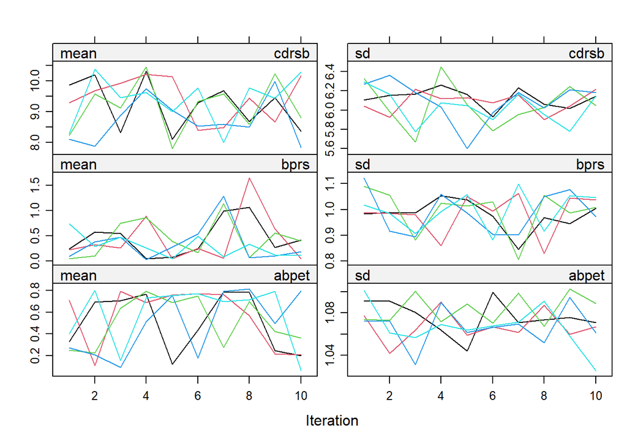

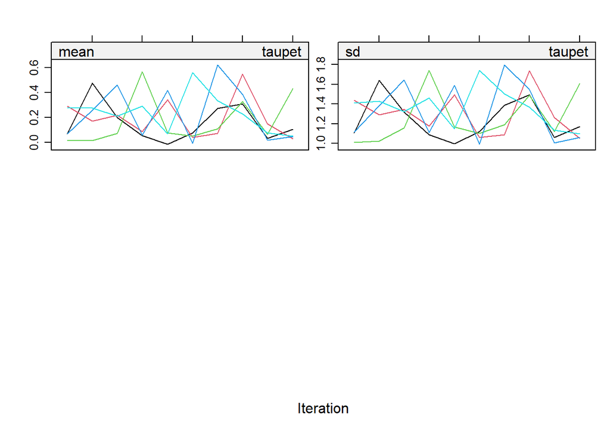

```r
plot(imp.1)
```

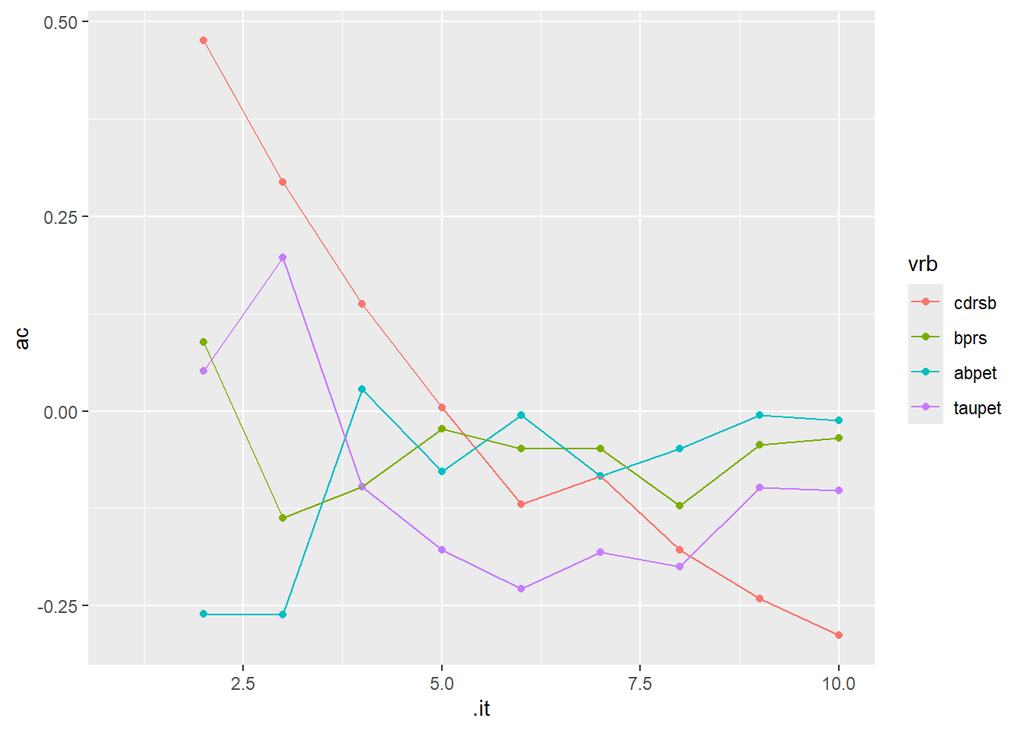

```r
ggplot(conv.imputed, aes(x = .it, y = ac, colour = vrb)) +
    geom_point() +
    geom_line()
```

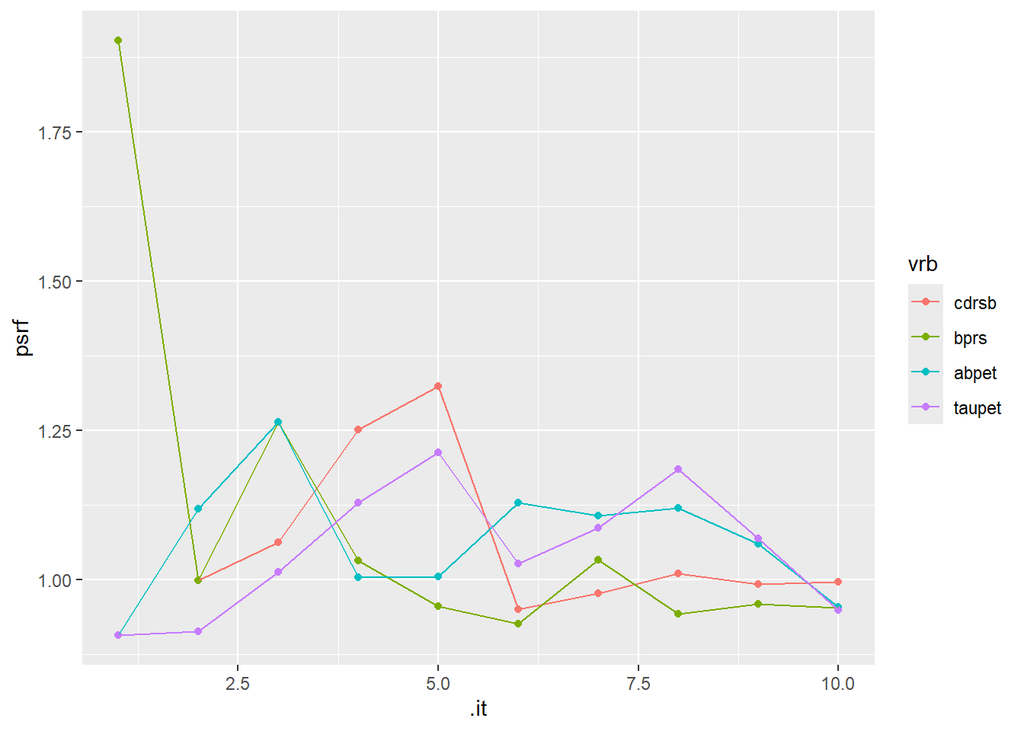

```r
ggplot(conv.imputed, aes(x = .it, y = psrf, colour = vrb)) +
    geom_point() +
    geom_line()
```

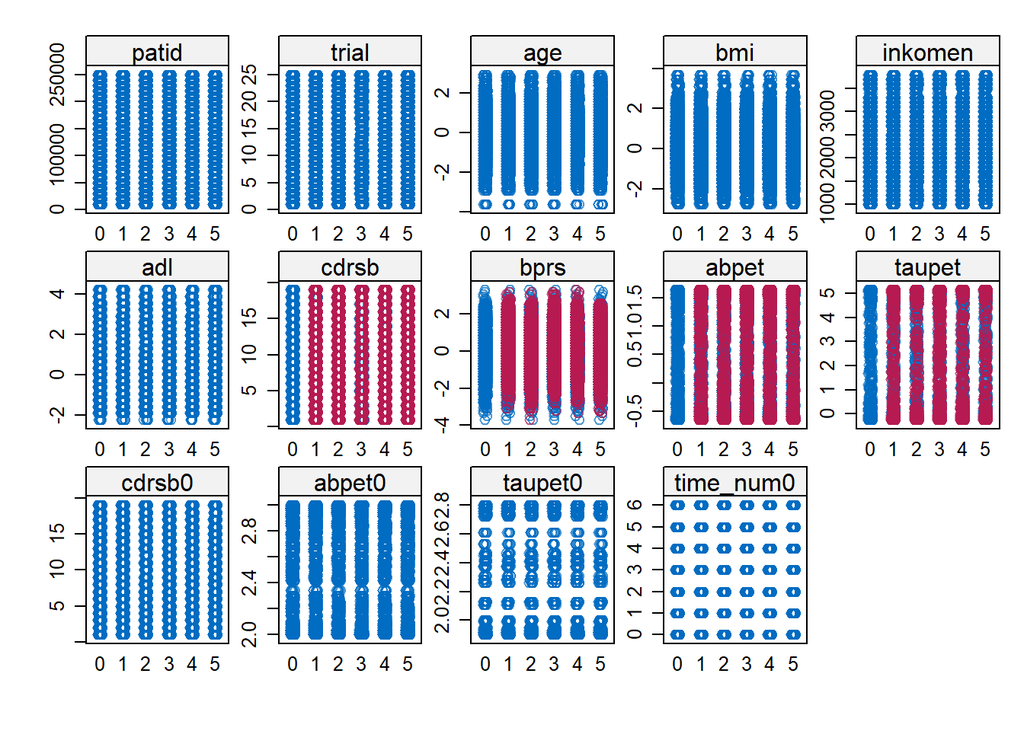

```r
stripplot(imp.1)
```

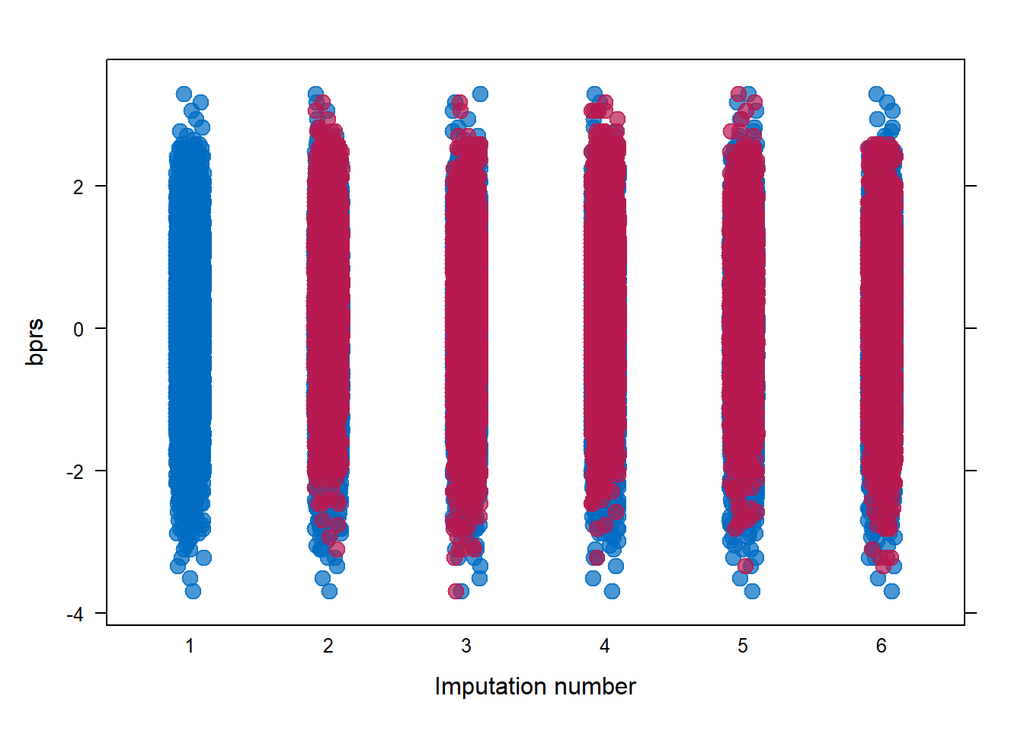

```r
stripplot(imp.1, bprs~.imp, pch=20, cex=2)  # blue: observed data, red: imputed data
```

#### Analysis

```r
implist <- mids2mitml.list(imp.1)

lmer_fits <- with(
  implist,
  expr = {
    lmerTest::lmer(
      bprs ~ as.numeric(time) * (sex + age + adl + job + cdrsb0) +  # time_num0
        wzc + taupet + abpet0 +
        (as.numeric(time) | trial/patid),
      REML = FALSE
    )
  }
)
```

```
## boundary (singular) fit: see help('isSingular')
```

```
## boundary (singular) fit: see help('isSingular')
## boundary (singular) fit: see help('isSingular')
## boundary (singular) fit: see help('isSingular')
## boundary (singular) fit: see help('isSingular')
```

```r
summary(mice::pool(lmer_fits))
```

```
##                       term      estimate   std.error    statistic        df
## 1              (Intercept) -2.980132e-01 0.117323598  -2.54009595 13.363547
## 2         as.numeric(time)  2.278866e-01 0.019563959  11.64828631  5.636050
## 3                     sex1  3.048359e-03 0.045053105   0.06766147 13.356420
## 4                      age  1.204255e+00 0.033172323  36.30299074 64.519738
## 5                      adl  3.224706e-01 0.044109167   7.31073987 43.947371
## 6                     job1 -1.154935e+00 0.109828871 -10.51577200 75.637086
## 7                   cdrsb0 -2.903178e-03 0.002665253  -1.08926932 20.072965
## 8                     wzc1  3.975063e-02 0.025588102   1.55348105 31.059919
## 9                   taupet  1.104636e-01 0.024077459   4.58784396  4.797609
## 10                  abpet0 -1.859838e-01 0.039112975  -4.75504031 39.481744
## 11   as.numeric(time):sex1 -2.651056e-03 0.030072657  -0.08815504  4.763573
## 12    as.numeric(time):age -1.178579e-01 0.019625910  -6.00522027  5.472994
## 13    as.numeric(time):adl  4.793924e-02 0.015248433   3.14387973 16.484213
## 14   as.numeric(time):job1 -4.382479e-02 0.034560122  -1.26807397 37.846364
```

[output cut: 17 more lines]

```r
results <- testEstimates(lmer_fits, extra.pars = T)
lmer_results_df <- as.data.frame(results$estimates)  # different degrees of freedom obtained than with pool()


save(lmer_results_df, file = "./results/lmer_results.RData") # use load() function to load dataframe into environment
```

## For GLMM:

##### Quadratic time with scaling and centering

```r
# Model 4: A random intercept and slope for patid, no random effects for trial
model_glmm <- glmer(cdrsb_bin ~ time_num0 + I(time_num0^2) + age + sex + bmi + adl + abpet + taupet + bprs + (time_num0 | patid_fct),
                data = dat_long_bin_scaled,
                family = binomial(link = "logit"),
                nAGQ = 1,
                control = glmerControl(optimizer = "bobyqa"))

summary(model_glmm)
```

```
## Generalized linear mixed model fit by maximum likelihood (Laplace
##   Approximation) [glmerMod]
##  Family: binomial  ( logit )
## Formula: cdrsb_bin ~ time_num0 + I(time_num0^2) + age + sex + bmi + adl +
##     abpet + taupet + bprs + (time_num0 | patid_fct)
##    Data: dat_long_bin_scaled
## Control: glmerControl(optimizer = "bobyqa")
##
##       AIC       BIC    logLik -2*log(L)  df.resid
##    6572.5    6660.1   -3273.3    6546.5      6207
##
## Scaled residuals:
##     Min      1Q  Median      3Q     Max
## -1.8852 -0.4899 -0.1812  0.4658  2.5747
##
## Random effects:
##  Groups    Name        Variance Std.Dev. Corr
##  patid_fct (Intercept) 17.721   4.210
##            time_num0    1.735   1.317    -0.99
## Number of obs: 6220, groups:  patid_fct, 1253
##
## Fixed effects:
##                Estimate Std. Error z value Pr(>|z|)
## (Intercept)    -2.75040    0.22839 -12.042  < 2e-16 ***
## time_num0       0.52227    0.10983   4.755 1.98e-06 ***
## I(time_num0^2)  0.04157    0.01284   3.237  0.00121 **
## age             0.03161    0.14643   0.216  0.82908
## sex1           -0.09127    0.08801  -1.037  0.29974
## bmi             0.02236    0.04270   0.524  0.60059
## adl            -0.01581    0.05336  -0.296  0.76705
## abpet          -0.03540    0.06853  -0.517  0.60545
## taupet          0.04616    0.04714   0.979  0.32747
## bprs           -0.15677    0.15716  -0.998  0.31851
## ---
## Signif. codes:  0 '***' 0.001 '**' 0.01 '*' 0.05 '.' 0.1 ' ' 1
##
## Correlation of Fixed Effects:
##             (Intr) tm_nm0 I(_0^2 age    sex1   bmi    adl    abpet  taupet
## time_num0   -0.863
## I(tm_nm0^2)  0.298 -0.630
## age         -0.405  0.503  0.040
## sex1        -0.152 -0.043 -0.001 -0.062
## bmi         -0.024  0.035  0.018  0.098  0.018
## adl          0.030 -0.070 -0.059  0.158  0.228  0.085
## abpet       -0.123  0.095  0.019 -0.172 -0.091 -0.024 -0.194
## taupet      -0.023  0.058 -0.112 -0.058 -0.020  0.003 -0.079 -0.165
## bprs         0.511 -0.594 -0.009 -0.815  0.099 -0.058  0.149 -0.239 -0.060
```

#### Mice

###### Mice setup

```r
# prepare dataframe (wide format)
dat_mice <- dat_long_bin_scaled %>%
    select(-patid_fct, -time, -time_num) %>%
    mutate(
    patid = as.integer(patid),  # make sure grouping variables are  integer
    trial = as.integer(trial)
    )

# imputation method
meth <- make.method(dat_mice)
# set method for all incomplete vars except bprs to 0 -> dont impute
meth[c("taupet", "abpet", "cdrsb", "bprs")] <- "2l.pmm"
meth[c("cdrsb_bin")] <- "logreg"

meth
```

```
##     patid     trial       sex       age       edu       bmi   inkomen       job
##        ""        ""        ""        ""        ""        ""        ""        ""
##       adl       wzc     cdrsb      bprs     abpet    taupet    cdrsb0    abpet0
##        ""        ""  "2l.pmm"  "2l.pmm"  "2l.pmm"  "2l.pmm"        ""        ""
##   taupet0 time_num0 cdrsb_bin
##        ""        ""  "logreg"
```

```r
# predictor matrix
pred <- make.predictorMatrix(dat_mice)
pred[, "patid"] <- -2  #
pred[, "trial"] <- -2
pred[, "taupet0"] <- 0
pred[, "abpet0"]  <- 0
pred[, "cdrsb0"]  <- 0
```

###### Imputation

```r
imp.glmm <- mice(dat_mice, method = meth, predictorMatrix = pred, m = 5, donors = 5, maxit = 10, seed = 1212, print = F)
```

[output not shown]

###### Post-imputation diagnostics

```r
conv <- convergence(imp.1, diagnostic = "all")

conv.imputed <- conv %>%
    filter(vrb %in% c("abpet", "taupet", "cdrsb", "bprs"))

conv.imputed
```

```
##    .it    vrb           ac      psrf
## 1    1  cdrsb           NA 1.9025136
## 2    2  cdrsb  0.475528532 0.9977309
## 3    3  cdrsb  0.293898555 1.0620044
## 4    4  cdrsb  0.137366556 1.2505571
## 5    5  cdrsb  0.003973524 1.3231343
## 6    6  cdrsb -0.119397139 0.9496109
## 7    7  cdrsb -0.083220130 0.9762527
## 8    8  cdrsb -0.178157753 1.0100167
## 9    9  cdrsb -0.240612594 0.9912436
## 10  10  cdrsb -0.288316931 0.9954907
## 11   1   bprs           NA 1.9025136
## 12   2   bprs  0.088329062 0.9977309
## 13   3   bprs -0.137453762 1.2638537
## 14   4   bprs -0.097414970 1.0319592
```

[output cut: 26 more lines]

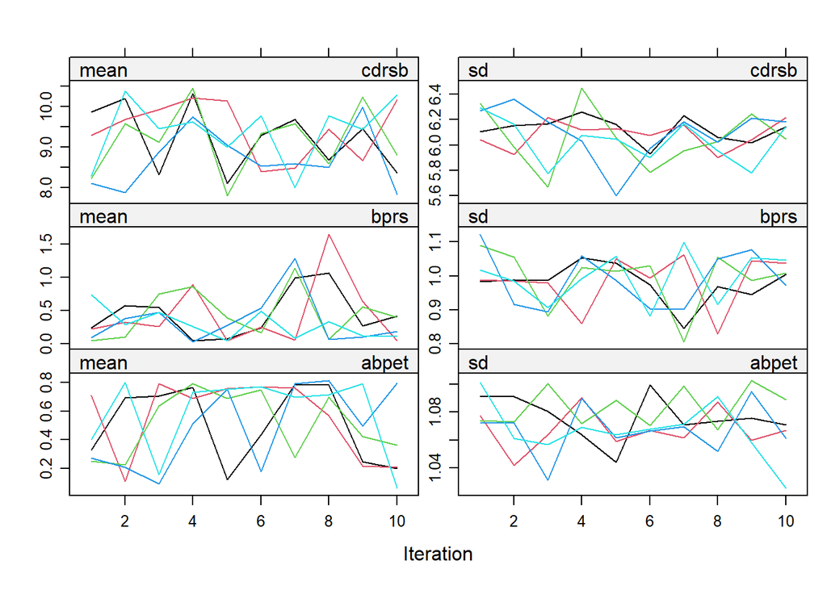

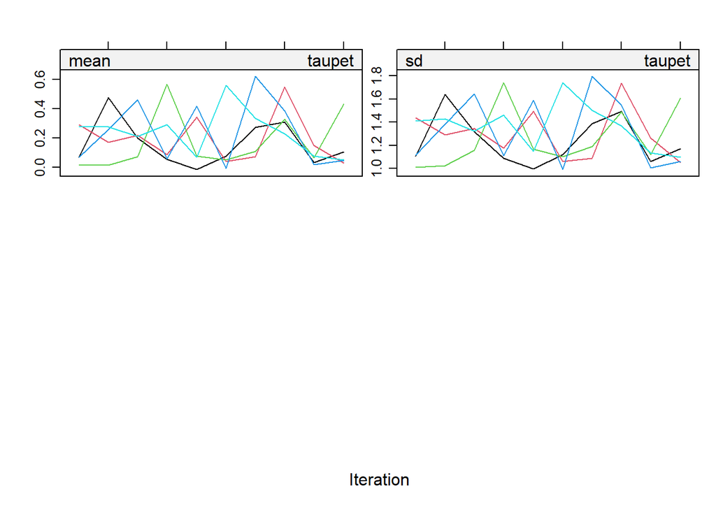

```r
plot(imp.1)
```

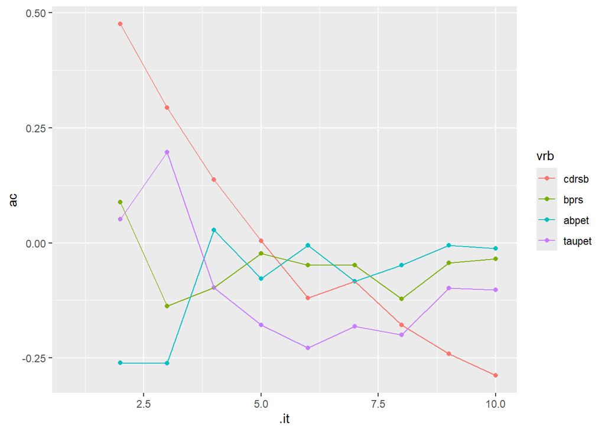

```r
ggplot(conv.imputed, aes(x = .it, y = ac, colour = vrb)) +
    geom_point() +
    geom_line()
```

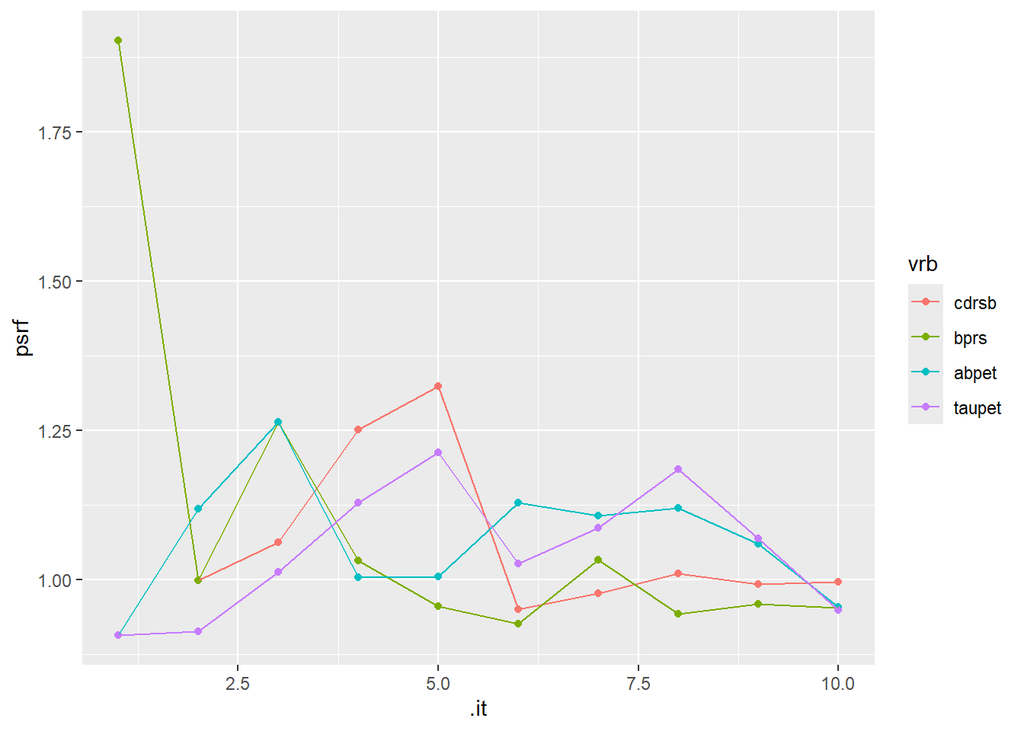

```r
ggplot(conv.imputed, aes(x = .it, y = psrf, colour = vrb)) +
    geom_point() +
    geom_line()
```

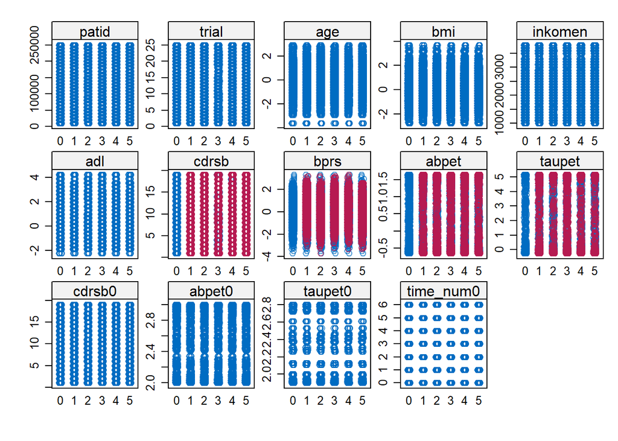

```r
stripplot(imp.1)
```

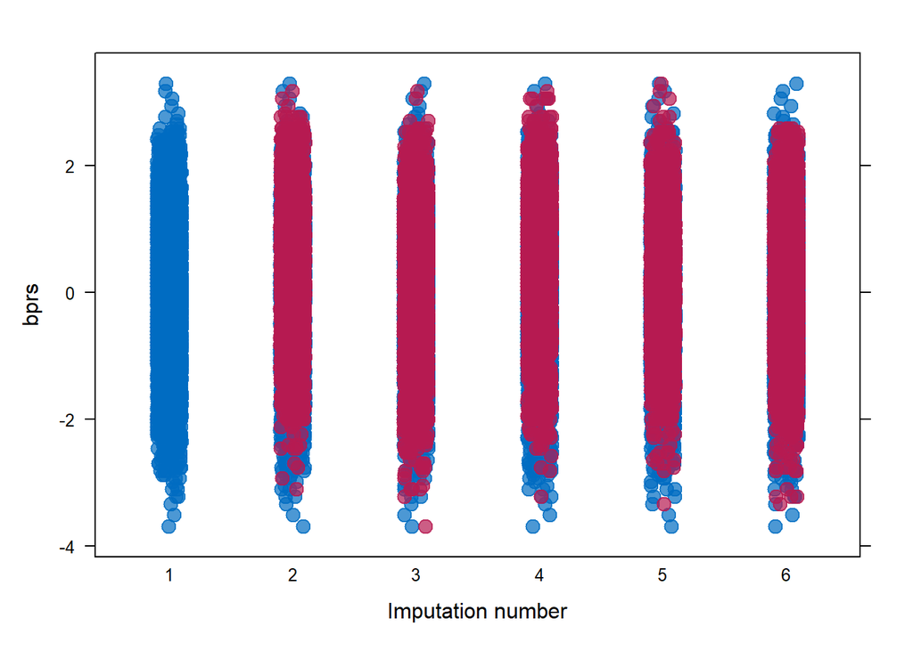

```r
stripplot(imp.1, bprs~.imp, pch=20, cex=2)  # blue: observed data, red: imputed data
```

##### Analysis

```r
library(broom.mixed)  # run this before pool() argument to prevent error message

implist <- mids2mitml.list(imp.glmm)

glmm_fits <- with(
  implist,
  expr = {
      glmer(cdrsb_bin ~ time_num0 + I(time_num0^2) + age + sex + bmi + adl + abpet + taupet + bprs + (time_num0 | patid),  # patid should be factor
                family = binomial(link = "logit"),
                nAGQ = 1,
                control = glmerControl(optimizer = "bobyqa"))

  }
)
summary(mice::pool(glmm_fits))
```

```
##              term     estimate  std.error   statistic       df     p.value
## 1     (Intercept) -1.546251822 0.27763171 -5.56943520 4.675608 0.003171805
## 2       time_num0  0.306314904 0.16765445  1.82706094 4.417931 0.134903593
## 3  I(time_num0^2)  0.006513676 0.03038635  0.21436193 4.185243 0.840306911
## 4             age  0.014405708 0.27174419  0.05301202 4.033806 0.960243969
## 5            sex1 -0.161518749 0.12820133 -1.25988355 4.902520 0.264356195
## 6             bmi  0.054492008 0.07046063  0.77336819 5.022390 0.474112809
## 7             adl  0.005456755 0.07298814  0.07476221 5.496741 0.943049568
## 8           abpet -0.025153800 0.07332937 -0.34302493 5.062570 0.745365323
## 9          taupet  0.021955313 0.04155767  0.52830947 7.441448 0.612670253
## 10           bprs  0.039479919 0.21270134  0.18561199 3.985759 0.861811905
```

```r
results <- testEstimates(glmm_fits, extra.pars = T)
glmm_results_df <- as.data.frame(results$estimates)  # different degrees of freedom obtained than with pool()


save(glmm_results_df, file = "./results/glmm_results.RData")  # use load() function to load dataframe into environment
```

## For GEE:

```r
model_gee <- geeglm(as.numeric(as.character(cdrsb_bin)) ~ time_num0 + I(time_num0^2) + taupet + adl + abpet + age + sex + bmi,
                   id = patid_fct,
                   data = dat_long_bin,
                   family = binomial,
                   corstr = "exchangeable")
summary(model_gee)
```

```
##
## Call:
## geeglm(formula = as.numeric(as.character(cdrsb_bin)) ~ time_num0 +
##     I(time_num0^2) + taupet + adl + abpet + age + sex + bmi,
##     family = binomial, data = dat_long_bin, id = patid_fct, corstr = "exchangeable")
##
##  Coefficients:
##                 Estimate   Std.err   Wald Pr(>|W|)
## (Intercept)    -0.680353  0.592239  1.320  0.25065
## time_num0      -0.133152  0.040617 10.747  0.00104 **
## I(time_num0^2)  0.068571  0.007349 87.062  < 2e-16 ***
## taupet          0.226867  0.204215  1.234  0.26660
## adl            -0.004836  0.010827  0.199  0.65513
## abpet           0.046232  0.114520  0.163  0.68643
## age            -0.013243  0.007302  3.289  0.06973 .
## sex1           -0.093976  0.057495  2.672  0.10215
## bmi             0.009229  0.012385  0.555  0.45614
## ---
## Signif. codes:  0 '***' 0.001 '**' 0.01 '*' 0.05 '.' 0.1 ' ' 1
##
## Correlation structure = exchangeable
## Estimated Scale Parameters:
##
##             Estimate Std.err
## (Intercept)        1 0.01866
##   Link = identity
##
## Estimated Correlation Parameters:
##         Estimate  Std.err
## alpha -0.0003673 0.007401
## Number of clusters:   1253  Maximum cluster size: 7
```

```r
exp(coef(model_gee))
```

```
##    (Intercept)      time_num0 I(time_num0^2)         taupet            adl
##         0.5064         0.8753         1.0710         1.2547         0.9952
##          abpet            age           sex1            bmi
##         1.0473         0.9868         0.9103         1.0093
```

As we have already imputed the missing values for the glmm analysis, we don’t need to redo the imputations, we can analyse right away:

#### Analysis

```r
implist <- mids2mitml.list(imp.glmm)

gee_fits <- with(
  implist,
  expr = {
   geeglm(as.numeric(as.character(cdrsb_bin)) ~ time_num0 + I(time_num0^2) + taupet + adl + abpet + age + sex + bmi,
                   id = patid,
                   family = binomial,
                   corstr = "exchangeable")
  }
)

summary(mice::pool(gee_fits))
```

```
##             term   estimate std.error statistic     df   p.value
## 1    (Intercept) -0.9040689   0.09548  -9.46898 19.727 8.917e-09
## 2      time_num0  0.0575626   0.11874   0.48477  5.085 6.480e-01
## 3 I(time_num0^2)  0.0272475   0.02481   1.09825  4.451 3.279e-01
## 4         taupet  0.0342363   0.03735   0.91667 11.930 3.775e-01
## 5            adl  0.0051900   0.05915   0.08774  7.629 9.323e-01
## 6          abpet  0.0007216   0.06462   0.01117  7.694 9.914e-01
## 7            age -0.0067860   0.15137  -0.04483  4.604 9.661e-01
## 8           sex1 -0.1276265   0.12070  -1.05738  5.749 3.327e-01
## 9            bmi  0.0449596   0.05550   0.81002  5.847 4.496e-01
```

```r
results <- testEstimates(gee_fits, extra.pars = T)
gee_results_df <- as.data.frame(results$estimates)  # different degrees of freedom obtained than with pool()

save(gee_results_df, file = "./results/gee_results.RData") # use load() function to load dataframe into environment
```